# Лабораторная работа №12

Настройки сети в Linux

Юсупова К. Р.

Российский университет дружбы народов, Москва, Россия

# Информация

## Докладчик

- Юсупова Ксения Равилевна
- Российский университет дружбы народов
- Номер студенческого билета- 1132247531
- [1132247531@pfur.ru]

# Вводная часть

## Цель работы

Получить навыки настройки сетевых параметров системы

# Выполнение лабораторной работы

Получили права администратора. Проверили сетевые подключения, статистику пакетов и маршрутизацию. Интерфейс enp0s3 активен с адресом 10.0.2.15/24, шлюзом 10.0.2.2. Передача данных без ошибок

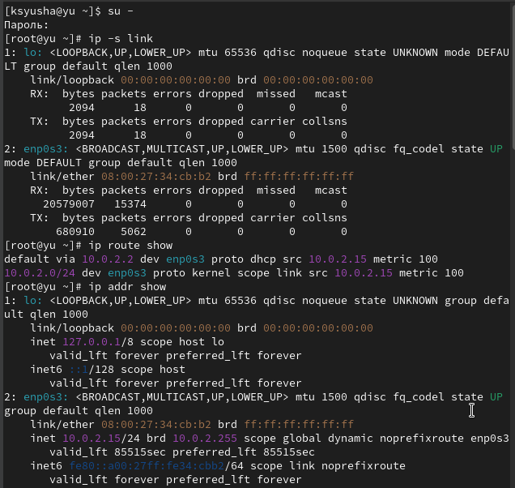

Выполнили пункты 1-4 из раздела 12.4.1. (Проверка конфигурации сети)

## Выполнение лабораторной работы

Использовали команду ping для проверки правильности подключения к Интернету. Отправили четыре пакета на IP-адрес 8.8.8.8. Добавили дополнительный адрес к вашему интерфейсу и проверили, что адрес добавился

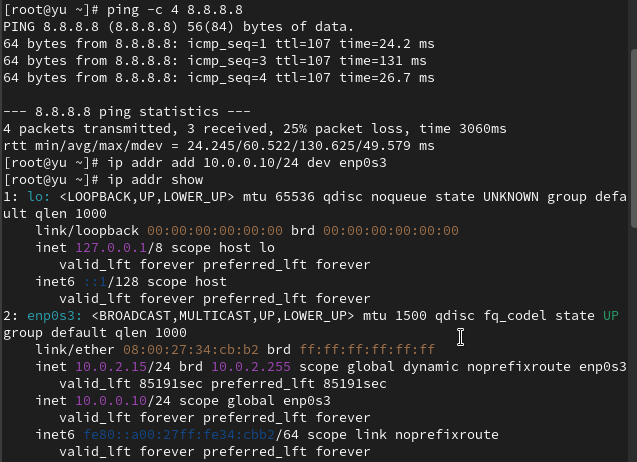

Выполнили пункты 5-7 из раздела 12.4.1. (Проверка конфигурации сети)

## Выполнение лабораторной работы

Сравнили вывод ip addr show и ifconfig. Команда ip показывает больше деталей, включая все адреса интерфейса. Проверили открытые порты системы

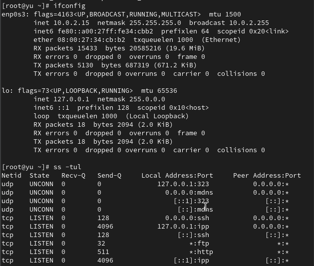

Выполнили пункты 8 и 9 из раздела 12.4.1. (Проверка конфигурации сети)

## Выполнение лабораторной работы

Получили полномочия администратора. Вывели на экран информацию о текущих соединениях, добавили Ethernet-соединение с именем dhcp к интерфейсу и добавили к этому же интерфейсу Ethernet-соединение с именем static, статическим IPv4-адресом адаптера и статическим адресом шлюза. Вывели информацию о текущих соединениях и переключились на статическое соединение, проверили успешность переключения при помощи nmcli connection show и ip addr. И вернулись к соединению dhcp, позже проверили успешность переключения при помощи nmcli connection show и ip addr

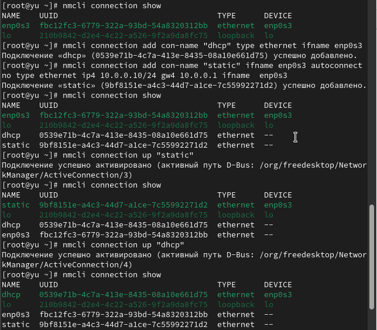

Выполнили пункты 1-6 из раздела 12.4.2. (Управление сетевыми подключениями с помощью nmcli)

## Выполнение лабораторной работы

Настроили статическое соединение: отключили автоподключение, добавили DNS-серверы 8.8.8.8 и 10.0.0.10, изменили IP-адрес

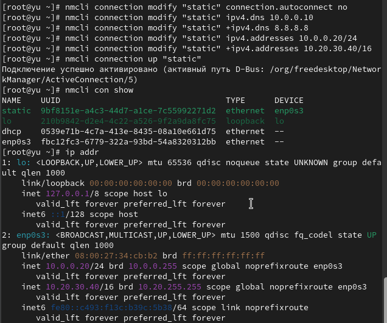

Выполнили пункты 1- 6 из раздела 12.4.3. (Изменение параметров соединения с помощью nmcli)

## Выполнение лабораторной работы

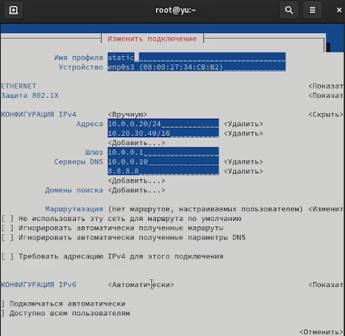

Выполнили пункт 8 и 9 из раздела 12.4.3. (Изменение параметров соединения с помощью nmcli)

## Выполнение лабораторной работы

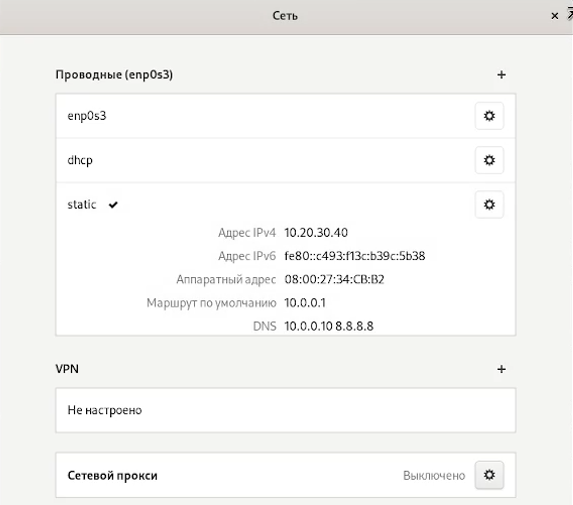

Выполнили пункт 10-12 из раздела 12.4.3. (Изменение параметров соединения с помощью nmcli)

## Выполнение лабораторной работы

Переключились на первоначальное сетевое соединение

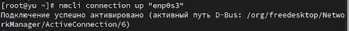

# Ответы на контрольные вопросы

1. ip link show - отображает статус интерфейсов без IP-адресов.
2. NetworkManager - основная служба управления сетью в RHEL и производных.
3. /etc/hostname - содержит постоянное имя узла.
4. hostnamectl set-hostname <имя> - устанавливает имя узла.
5. /etc/hosts - для статического разрешения имён.
6. ip route show - показывает таблицу маршрутизации.
7. systemctl status NetworkManager - проверяет статус службы.
8. nmcli connection modify - изменяет параметры подключения (например: nmcli con mod “подключение” ipv4.addresses 192.168.1.10/24 ipv4.gateway 192.168.1.1).

# Выводы

В ходе лабораторной работы мы получили навыки настройки сетевых параметров системы.